# World Population Analysis: Learning to use SQL and SQLite with pandas

Using the World Population Database, a public dataset that contains information on the population and demographics of countries around the world, create a column chart of population by year for the country you live in. There are two tables in this database: population and country_mapping.

Here is the column description for the population table:

| Column Name | Description | Unit |
| --- | --- | --- |
| CountryCode | Three Character Country Code | NA |
| CountryName | Full Name of the Country | NA |
| Year | Year | NA |
| Population | Total Population, as of 1 July | thousands |
| PopulationMale | Male Population, as of 1 July | thousands |
| PopulationFemale | Female Population, as of 1 July | thousands |
| PopDensity | Population Density, as of 1 July | persons per square km |
| PopSexRatio | Population Sex Ratio, as of 1 July | males per 100 females |
| MedianAge | Median Age, as of 1 July | years |
| PopChange | Population Change | thousands |
| GrowthRate | Population Growth Rate | percentage |
| DoublingTime | Population Annual Doubling Time | years |

Here is the column description for the country_mapping table:

| Column Name | Description | Unit |
| --- | --- | --- |
| CountryCode | Three Character Country Code | NA |
| CountryName | Name of the country | NA |
| Region | Continent that the country belongs to | NA |
| SubRegion | Sub Region within the continent | NA |

[*Data Source*](https://population.un.org/wpp/downloads?folder=Standard%20Projections&group=Most%20used)

```python
import pandas as pd
import sqlite3
import matplotlib.pyplot as plt
```

```python
# Establish a connection to the database
conn = sqlite3.connect('world_population.db')
```

```python
# Get information about the tables in the database
query = 'PRAGMA table_info(population)'
results = pd.read_sql_query(query, conn)
print(results)

query = 'PRAGMA table_info(country_mapping)'
results = pd.read_sql_query(query, conn)
print(results)
```

```
    cid              name     type  notnull dflt_value  pk
0     0       CountryCode     TEXT        1       None   0
1     1       CountryName     TEXT        1       None   0
2     2              Year  INTEGER        0       None   0
3     3        Population     REAL        0       None   0
4     4    PopulationMale     REAL        0       None   0
5     5  PopulationFemale     REAL        0       None   0
6     6        PopDensity     REAL        0       None   0
7     7       PopSexRatio     REAL        0       None   0
8     8         MedianAge     REAL        0       None   0
9     9         PopChange     REAL        0       None   0
10   10        GrowthRate     REAL        0       None   0
11   11      DoublingTime     REAL        0       None   0
   cid         name  type  notnull dflt_value  pk
0    0  CountryCode  TEXT        1       None   0
1    1  CountryName  TEXT        1       None   0
2    2       Region  TEXT        0       None   0
3    3    SubRegion  TEXT        0       None   0
```

### Retrieve the population of all countries in 2020. Include the CountryName and Population fields. Limit the results to 10 rows.

```python
# Define the SQL query
query = """SELECT CountryName, Population
           FROM population
          WHERE Year = 2020
          LIMIT 10;"""
# Execute the query and read results into a dataframe
results = pd.read_sql_query(query, conn)
print(results)
```

```
           CountryName  Population
0          Afghanistan   38972.230
1              Albania    2866.848
2              Algeria   43451.666
3       American Samoa      46.189
4              Andorra      77.700
5               Angola   33428.486
6             Anguilla      15.585
7  Antigua and Barbuda      92.664
8            Argentina   45036.032
9              Armenia    2805.608
```

### Retrieve the population data for your country for all years. Include the CountryName, Year, and Population columns in the results.

```python
# Define SQL query
query = '''
        SELECT CountryName, Year, Population
          FROM population
         WHERE CountryName = 'United States of America'
         '''
# Execute the query and read results into a dataframe
results = pd.read_sql_query(query, conn)
print(results[:10])
```

```
                CountryName  Year  Population
0  United States of America  1950  148281.550
1  United States of America  1951  150598.453
2  United States of America  1952  152941.727
3  United States of America  1953  155451.199
4  United States of America  1954  158205.873
5  United States of America  1955  161136.449
6  United States of America  1956  164063.411
7  United States of America  1957  166949.120
8  United States of America  1958  170147.101
9  United States of America  1959  173324.608
```

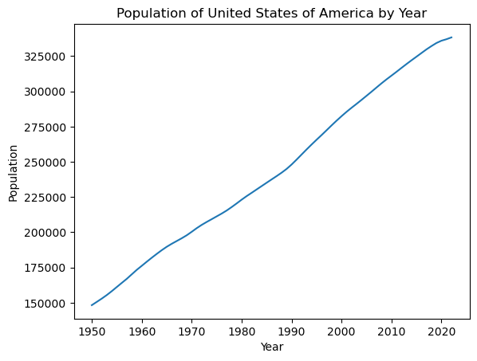

```python
# Create a plot by year
plt.plot(results['Year'],results['Population'])
plt.xlabel("Year")
plt.ylabel("Population")
plt.title("Population of United States of America by Year")
plt.show()
```

### Select data from the population and country_mapping tables to find the top ten subregions with the most significant change in population from 2010 to 2020. Create a horizontal bar chart to visualize the results.

Steps breakdown:

- Output table needs to have these columns: Region, SubRegion and Sum of PopChange
- We need to group data by Region and SubRegion
- Filter the data for only 2010 to 2020
- Sort the Sum of PopChange column and retreive only the top 10 sub-regions with most significant change in population during those years
- Create a horizontal bar chart with SubRegion on Y-axis and sum of PopChange on X-axis

```
     Region                        SubRegion   PopChange
0    Africa               Sub-Saharan Africa  287356.950
1      Asia                    Southern Asia  257227.153
2      Asia                     Eastern Asia   85339.693
3      Asia               South-eastern Asia   77135.592
4  Americas  Latin America and the Caribbean   66884.346
5      Asia                     Western Asia   51913.747
6    Africa                  Northern Africa   48443.667
7  Americas                 Northern America   30848.170
8      Asia                     Central Asia   12205.477
9    Europe                   Western Europe    7568.351
```

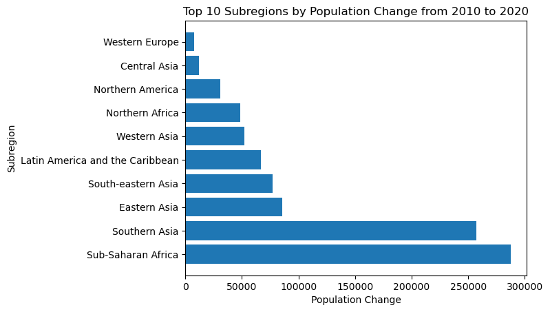

```python
# Define SQL query
query = '''
        SELECT cm.Region, cm.SubRegion, SUM(p.PopChange) AS PopChange
          FROM country_mapping AS cm
          JOIN population AS p
            ON cm.CountryCode = p.CountryCode
         WHERE p.Year BETWEEN 2010 AND 2020
         GROUP BY cm.Region, cm.SubRegion
         ORDER BY PopChange DESC
         LIMIT 10;'''
# Execute the query and read results into a dataframe
results = pd.read_sql_query(query, conn)
print(results)

# Create horizontal bar plot
plt.barh(results['SubRegion'], results['PopChange'])
plt.xlabel('Population Change')
plt.ylabel('Subregion')
plt.title('Top 10 Subregions by Population Change from 2010 to 2020')
plt.show()
```

```python
# Close the connection to the database
conn.close()
```